# Networks and QBME

Ernesto Carrella

December 8, 2015

## QBME Workflow

We can use model optimization for more than just look at optimal policies.

Currently the workflow of the project is more or less as follows: I implement something, I check what happens and if it interesting I wrote a little html document showcasing it. This is the “traditional” ABM workflow. It will become harder and harder to find something “interesting” as the parameters start interacting with one another in non-obvious ways.  
The other approach is the QBME approach: to specify a metric of what is interesting and then to let the (Bayesian) optimizer find which parameters create that interesting behavior. A nice figure (from [here](http://jasss.soc.surrey.ac.uk/18/4/4.html)) summarizes it well.

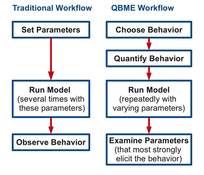

This is something cool people in the ABM community talk a bit about but rarely actually do and it’s nice that we have it implemented early enough.

## Swapping Friends

Here I show a very simple example of how the QBME workflow looks like. The world is split perfectly so that red fish live only in the north part of the world and blue fish live only on the south side. Agents are randomly given a gear that either catches only reds or only blues.

Let’s further say that what we are interested in is to create a network that is very segregated so that blue fishers are friends with only blue fishers and viceversa. So that we want to maximize:
$$\frac{\text{Same Gear Connections}}{\text{All Connections}}$$
After about 30 experiments the Bayesian optimization finds a relatively obvious solution:

- Degree: 1
- Imitation: irrelevant
- Threshold: $\delta=0.0276$

Which means basically change your one friend only if imitation made you extremely worse off. This is how the social network looks like at the beginning of a simulation:

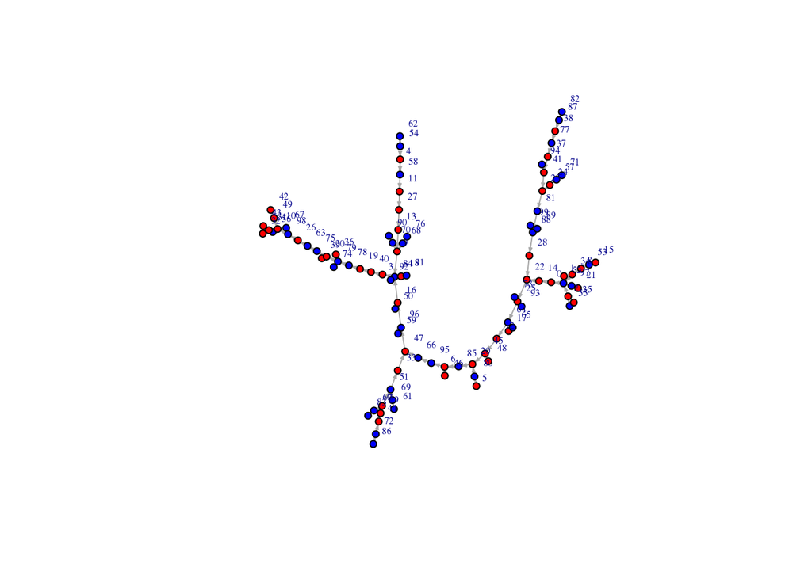

A relatively random graph where everybody has a random friend (red nodes have red-only gear and blue nodes have blue-only gear). By the end of 20 years the friendship network looks extremely segregated:

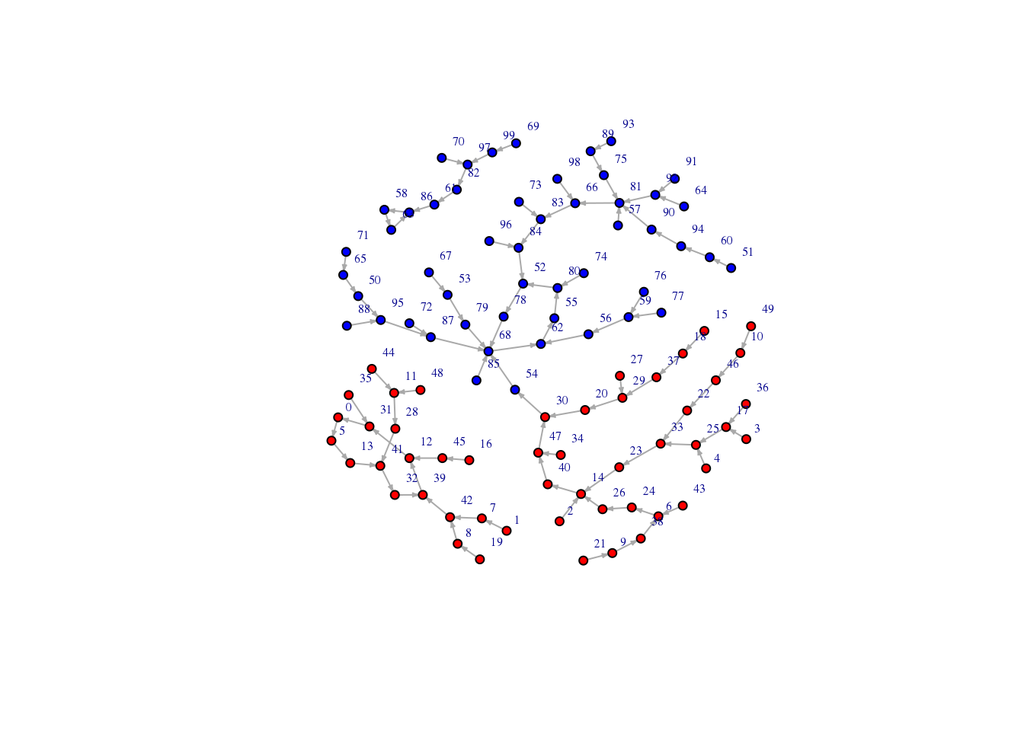

So we can input what we would like to see, segregated networks, and let the optimizer find the parameters that would generate that.  
And of course, because we are using a Bayesian optimizer, we can plot our posterior to get an idea of what variables matter the most (and in this case it’s all about the $\delta$)

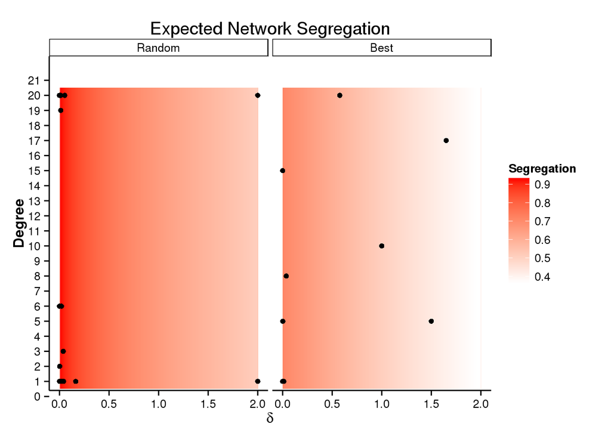